# **S2 - El impacto económico de los E-sports en los últimos 20 años a nivel mundial**

### Grafica de regresión

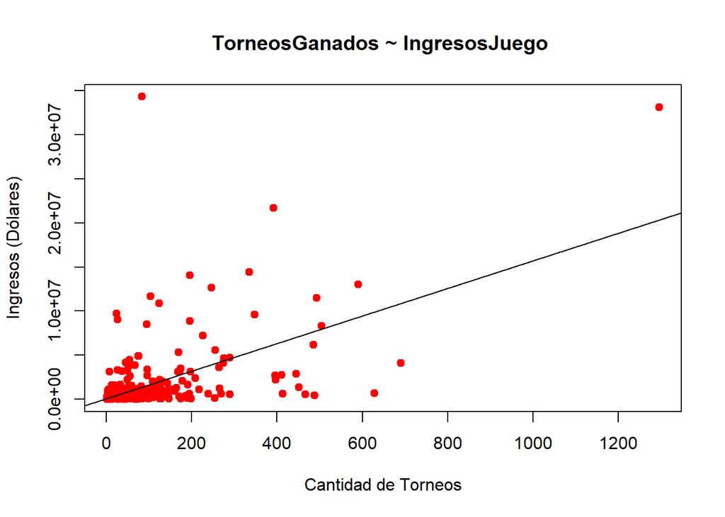

```r
plot(tournaments_income$TorneosGanados, tournaments_income$IngresosJuego , pch = 19, col = "red", xlab="Cantidad de Torneos", ylab="Ingresos (Dólares)", main="TorneosGanados ~ IngresosJuego ")
abline(regresion3)
# Correlación de Pearson
text(paste("Correlación:", round(cor(tournaments_income$TorneosGanados, tournaments_income$IngresosJuego , use = "complete.obs"), 2)), x = 5500, y = 150000000)
```

### Correlación entre variables

```r
cor(tournaments_income$TorneosGanados,tournaments_income$IngresosJuego, use = "complete.obs")
```

```
## [1] 0.5812346
```

La correlación entre las variables es 0.5812346 lo que indica una proporcionalidad directa o positiva moderada debido a que es mayor que 0.4 pero menor a 0.7.

# **Conclusiones**

El estudio sobre el éxito de los ESports es amplio y requiere de grandes cantidades de datos para poder llegar conclusiones relevantes. Por lo que el uso de diferentes datasets se vuelve una necesidad para cualquier proyecto de investigación.

Con respecto a las preguntas de investigación planteadas al comienzo del proyecto, se consiguió responder las siguientes interrogantes:

- **¿Ha aumentado el número de torneos de E-sport en los últimos 20 años?**
  - Un indicador de que el número de torneos se ha incrementado se realizó en nuestra prueba de hipótesis. En esta se indicó que el promedio de número de torneos realizados por mes es superior a 200 con un nivel de confianza del 99%.
  - De igual manera, en la gráfica **N°ro de torneos** se observó que existe un gran sesgo a la derecha. Esto es un indicador de que el número de torneos aumentó en los últimos 20 años de manera explosiva ocasionando que la mediana aún no se normalice con la media de los torneos por mes.
- **¿Ha aumentado el número de ganadores de torneos de E-sport?**
  - En nuestra prueba de hipótesis de la variable **TorneosGanados**, no se pudo rechazar la hipótesis con un nivel de confianza del 99% de que la media de torneos ganadoes es **menor o igual** a 60 por equipo/empresa profesional de ESports.
  - Sin embargo, en la gráfica **TorneosGanados** correspondiente a esa hipótesis, se observó que existe un gran sesgo a la derecha. Esto se debe a que exiten equipos como Cloud9 del juego de League of Legends que influyen de manera significativa en la media de torneos ganados. Por lo que se concluye que la inversión en equipos particulares de ESports sigue siendo una buena idea.
- **¿Ha aumentado la media de los premios ofrecidos en torneos de E-sport en los últimos 20 años?**
  - En nuestra prueba de hipótesis de la variable **Premios**, no se pudo rechazar la hipótesis con un nivel de confianza del 99% de que la media de premios ofrecidos en torneos es **menor o igual** a 100000 dólares.
  - Sin embargo, en la gráfica **Premios totales** correspondiente a esa hipótesis, se observó que existe un gran sesgo a la derecha. Esto se debe a que los torneos de videojuegos como Dota2 o CounterStrike influyen de manera significativa en el monto de premios ofrecidos y su media. Por lo que se concluyen que la inversión en tales juegos particulares y por ende en torneos de ESports sigue siendo una buena idea.